# Week 4: Clustering, cluster stability, and marker genes

Kevin Z. Lin

2026-08-15

> **A note on `cache = TRUE`, and on the `autodep` line next to it.** This document caches every chunk, so the first knit takes tens of minutes and every later one takes a couple. Three things are worth knowing before you rely on it.

> **Disk.** `knitr` re-saves every object a chunk *modifies*, and a 40,000-cell Seurat object is roughly a gigabyte, so `_cache/` reaches several GB. Two things keep that in check here. The steps that change the Seurat object are grouped into few chunks; and **every chunk whose only output is a figure is marked `cache=FALSE`**. That second one is not an aesthetic choice: a `ggplot` object stores the environment it was built in, so caching one can drag a copy of the entire Seurat object onto disk with it. Plots are cheap to redraw once the object is cached upstream, so there is nothing to gain by storing them. Also: if your project lives in Dropbox, OneDrive or Google Drive, exclude `_cache/` from syncing.

> **Interruption.** Stop a knit part-way and the cache can be left truncated, which surfaces on the next run as `error reading from connection`. Delete `_cache/` and knit again.

> **Staleness, which is the one that will actually cost you.** By default `knitr` caches each chunk independently and does **not** re-run a chunk when the objects it depends on change. Fix a bug upstream, re-knit, and a downstream figure can silently stay the *old* figure — a document whose prose and plots disagree, with nothing to warn you. `autodep = TRUE` with `knitr::dep_auto()` makes `knitr` track which chunks read which objects and invalidate accordingly. It is not perfect. Before a document leaves your hands, delete `_cache/` and knit once from clean.

# 1 Overview

This tutorial was made from the Seurat guided clustering vignette, https://satijalab.org/seurat/articles/pbmc3k_tutorial, and the Seurat differential expression vignette, https://satijalab.org/seurat/articles/de_vignette. The cluster-comparison, stability and marker-panel sections draw on the diagnostics used in production snRNA-seq pipelines for human brain tissue.

Week 1 clustered PBMCs on Seurat defaults and did not defend a single choice. Week 3 normalized properly and did batch correction. This tutorial takes the clustering step seriously, on a dataset where the defaults do not work: **40,000 microglial nuclei from 89 human donors.**

Three things make this harder than the vignette:

1. There is no ground truth. In PBMCs you can check your clusters against textbook immunology. Microglial states are an open research question, which is why people are running these experiments in the first place.
2. **The donors are a potential batch effect.** With 89 of them, an uncorrected analysis can produce clusters that are really describing a few individuals. Whether it *has* is a question you have to measure, not assume.
3. Cluster boundaries are a modelling output, not an observation. Change the resolution and you change how many cell types you “found”.

So this tutorial spends most of its time on a question the vignette never asks: **should you believe these clusters?**

The plan:

| Stage | What it produces | Function |
| --- | --- | --- |
| 1. The naive route | A PCA that has not been batch-corrected | `RunPCA()` |
| 2. Cluster it | Clusters, and a donor-purity problem | `FindClusters()` |
| 3. The corrected route | Clusters from an integrated embedding | `FindClusters()` on `scVI` |
| 4. Do they agree? | A concordance heatmap between the two | `table()`, `pheatmap()` |
| 5. Are they stable? | A per-cluster bootstrap coherence score | `bootstrapStability()` |
| 6. Pick a resolution | Clusters at several resolutions, compared | `FindClusters()` |
| 7. Name them | Marker genes, and known panels | `FindAllMarkers()`, `DotPlot()` |
| 8. Compare to a reference | Our clusters against SEA-AD’s labels | `table()` |

> **Where this sits in the workshop.** This is the second half of batch correction: Week 3 produced an integrated embedding and stopped; here we use one and ask whether it changed the answer. The companion Week 4 tutorial takes the labelled cells and tests genes between **donors**. Bulk deconvolution is **Week 5**.

# 2 Setting up

```r
# install.packages(c("Seurat", "ggplot2", "pheatmap", "patchwork"))
# if (!require("BiocManager", quietly = TRUE)) install.packages("BiocManager")
# BiocManager::install(c("bluster", "EnhancedVolcano"))
# devtools::install_github("immunogenomics/presto")  # makes wilcox much faster
```

```r
library(Seurat)
library(SeuratObject)
library(bluster)
library(EnhancedVolcano)
library(pheatmap)
library(patchwork)
library(ggplot2)
```

```r
rm(list = ls())
```

# 3 The data

**SEA-AD** (Seattle Alzheimer’s Disease Brain Cell Atlas) profiled middle temporal gyrus from an aged cohort spanning the full range of Alzheimer’s neuropathology. This file is the microglia and perivascular-macrophage subset, downsampled to 40,000 nuclei.

The file downloads itself into a temporary folder, so this tutorial runs as-is with nothing to set up. It is **525 MB**, so expect the first run to take a few minutes on a decent connection.

```r
data_dir <- tempdir(check = TRUE)

# If you have already downloaded seaad_microglia.RData, point data_dir at the
# folder holding it instead and the download below will be skipped, e.g.:
# data_dir <- "/path/to/your/data"
```

```r
options(timeout = 3600)

data_url <- paste0("https://www.dropbox.com/scl/fi/cei02rwh3gx61uu9zzeql/",
                   "seaad_microglia.RData",
                   "?rlkey=04erfwn3w2lrnr80pefwfh8fu&dl=1")
data_file <- file.path(data_dir, "seaad_microglia.RData")
expected_size <- 525672784

if (!file.exists(data_file) || file.size(data_file) != expected_size) {
  download.file(data_url, destfile = data_file, mode = "wb")
}

file.size(data_file) == expected_size
```

```
## [1] TRUE
```

> **Three details in that download, and every one of them has bitten someone.**

> **`options(timeout = 3600)`.** R’s default download timeout is **60 seconds**, which is not enough for half a gigabyte on any normal connection. Without this line the transfer dies partway through with `downloaded length 106201070 != reported length 525672784` — and because that arrives as a *warning* rather than an error, a script can sail past it and fail later at `load()` with a message about a corrupt file. This is the single most common reason a large `download.file()` “doesn’t work” in R.

> **`dl=1`, not `dl=0`.** Copying a Dropbox share link gives you `dl=0`, which serves the HTML preview page. You would download a web page, and `load()` would complain about a bad magic number.

> **`mode = "wb"`.** Forces a binary write. Without it the file is silently corrupted on Windows.

> The size comparison at the end is the point of all three: **verify the bytes you got are the bytes you wanted**, rather than trusting that no error appeared.

```r
load(data_file)
seurat_obj
```

```
## An object of class Seurat
## 36412 features across 40000 samples within 1 assay
## Active assay: RNA (36412 features, 0 variable features)
##  2 layers present: counts, data
##  2 dimensional reductions calculated: scVI, umap
```

Read that summary carefully — it tells you the work someone else already did.

```r
SeuratObject::Layers(seurat_obj[["RNA"]])
```

```
## [1] "counts" "data"
```

```r
Seurat::Reductions(seurat_obj)
```

```
## [1] "scVI" "umap"
```

Two layers, so the counts have already been log-normalized. Two reductions, and the interesting one is **`scVI`**: the SEA-AD authors integrated across donors with a variational autoencoder, and shipped the result. Week 3 named scVI as one of the methods it was deferring — here it is, pre-computed, which lets us treat it as a given and spend our time on what it changes.

```r
dim(Seurat::Embeddings(seurat_obj, "scVI"))
```

```
## [1] 40000    10
```

```r
dim(Seurat::Embeddings(seurat_obj, "umap"))
```

```
## [1] 40000     2
```

Ten latent dimensions. The `umap` is the authors’ UMAP built from those.

```r
length(unique(seurat_obj$donor_id))
```

```
## [1] 89
```

```r
table(seurat_obj$assay)
```

```
##
##    10x 3' v3 10x multiome
##        35889         4111
```

```r
table(seurat_obj$Supertype)
```

```
##
##         Micro-PVM_1 Micro-PVM_1_1-SEAAD         Micro-PVM_2 Micro-PVM_2_1-SEAAD
##                1621                 260               22427                 289
## Micro-PVM_2_2-SEAAD Micro-PVM_2_3-SEAAD   Micro-PVM_3-SEAAD   Micro-PVM_4-SEAAD
##                 855                9019                5107                 422
```

`Supertype` is SEA-AD’s own annotation. We will not look at it again until the end, where it becomes an independent check on clusters we derived without it.

> **Keeping a label in reserve is a method, not a nicety.** Week 3 used Azimuth labels the same way: to judge an embedding you need a read on cell identity that was not computed *from* that embedding. Anything you derive from the clustering cannot then be used to validate the clustering.

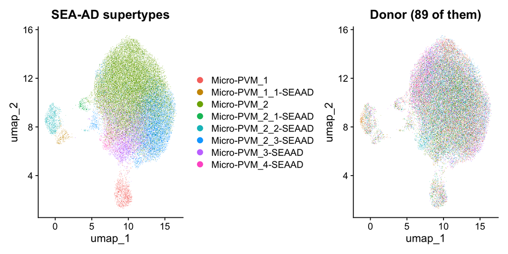

```r
gg1 <- Seurat::DimPlot(seurat_obj, reduction = "umap", group.by = "Supertype",
                       raster = TRUE) +
  ggplot2::ggtitle("SEA-AD supertypes")
gg2 <- Seurat::DimPlot(seurat_obj, reduction = "umap", group.by = "donor_id",
                       raster = TRUE) +
  Seurat::NoLegend() +
  ggplot2::ggtitle("Donor (89 of them)")
plot(gg1 + gg2)
```

# 4 The naive route: cluster without correcting for donor

First do what Week 1 taught, unchanged, and see where it fails. The data is already normalized, so we pick variable genes, scale, and run PCA.

```r
seurat_obj <- Seurat::FindVariableFeatures(seurat_obj,
                                           selection.method = "vst",
                                           nfeatures = 2000,
                                           verbose = FALSE)
seurat_obj <- Seurat::ScaleData(seurat_obj, verbose = FALSE)

set.seed(10)
seurat_obj <- Seurat::RunPCA(seurat_obj,
                             features = Seurat::VariableFeatures(seurat_obj),
                             npcs = 30,
                             verbose = FALSE)

seurat_obj[["RNA"]]$scale.data <- NULL

head(Seurat::VariableFeatures(seurat_obj), 20)
```

```
##  [1] "VCAN"            "HS3ST2"          "F13A1"           "SLC16A10"
##  [5] "ENSG00000227240" "IL1R2"           "THBS1"           "IL7R"
##  [9] "ENSG00000285744" "ENSG00000253557" "THEMIS"          "GALNTL6"
## [13] "CCL4"            "ADARB2"          "CERNA2"          "NR4A3"
## [17] "FGF13"           "ENSG00000286546" "MARCO"           "ENSG00000253496"
```

> **`ScaleData()` does not scale every gene.** By default it operates on `VariableFeatures()` only, which is why this is affordable on 40,000 cells. Scaling all 36,412 genes would build a dense matrix of about 11 GB.

> **And `scale.data` is disposable once the PCA exists.** Nothing downstream here reads it — `DotPlot()` and `FeaturePlot()` use the `data` layer, and the clustering uses the reduction — so we drop it. That is 2,000 × 40,000 doubles, about 640 MB, removed from every subsequent cache write. `DoHeatmap()` is the one common function that would need it back.

How many components to keep? Week 1 read an elbow off a plot. The same judgment can be automated by taking the first point where the standard deviation stops dropping appreciably. Both are shown here — the automated rule is useful precisely because it makes the choice explicit and reproducible.

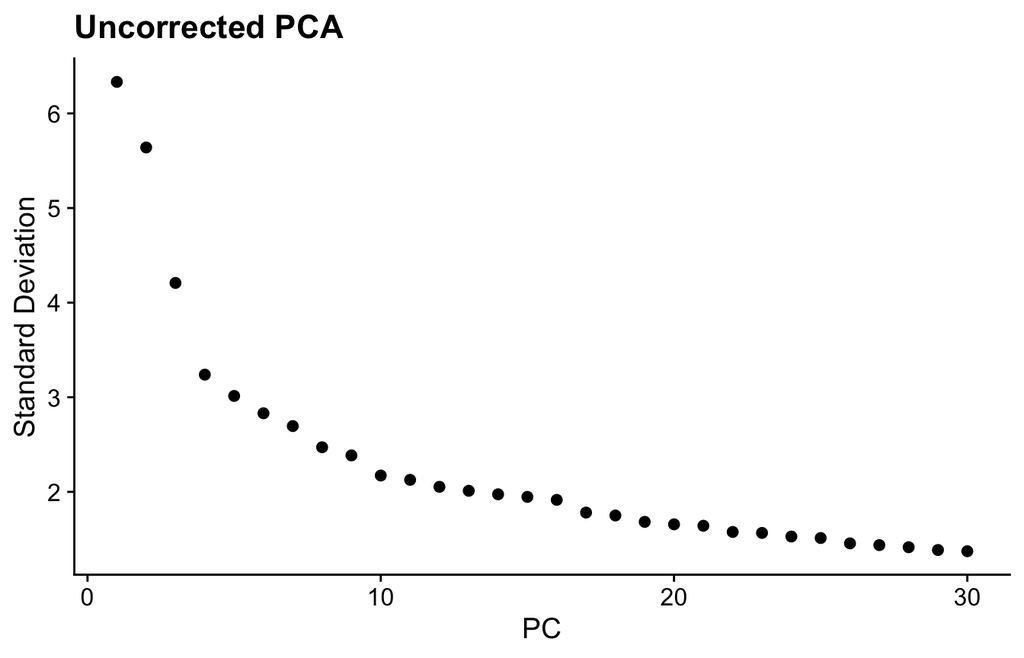

```r
gg <- Seurat::ElbowPlot(seurat_obj, ndims = 30) +
  ggplot2::ggtitle("Uncorrected PCA")
plot(gg)
```

```r
pca_stdev <- Seurat::Stdev(seurat_obj, reduction = "pca")
stdev_drop <- abs(diff(pca_stdev))

num_pcs <- min(which(stdev_drop < 0.1))
num_pcs
```

```
## [1] 8
```

```r
round(pca_stdev[1:15], 2)
```

```
##  [1] 6.33 5.64 4.21 3.24 3.01 2.83 2.70 2.47 2.39 2.17 2.13 2.05 2.01 1.97 1.95
```

```r
set.seed(10)
seurat_obj <- Seurat::FindNeighbors(seurat_obj,
                                    reduction = "pca",
                                    dims = 1:num_pcs,
                                    verbose = FALSE)
seurat_obj <- Seurat::FindClusters(seurat_obj,
                                   resolution = 0.5,
                                   cluster.name = "pca_clusters",
                                   verbose = FALSE)

set.seed(10)
seurat_obj <- Seurat::RunUMAP(seurat_obj,
                              reduction = "pca",
                              dims = 1:num_pcs,
                              reduction.name = "umap_pca",
                              verbose = FALSE)

table(seurat_obj$pca_clusters)
```

```
##
##    0    1    2    3    4    5    6    7    8    9   10   11
## 8136 5373 5053 4830 3835 3430 3018 2646 2210  796  370  303
```

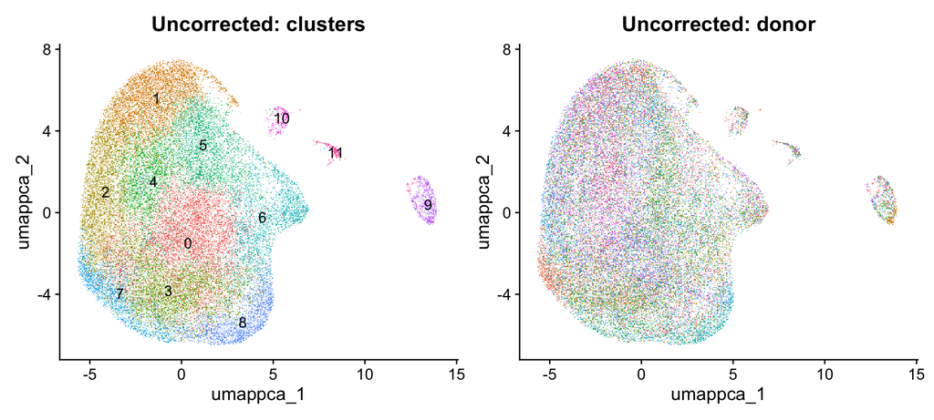

```r
gg1 <- Seurat::DimPlot(seurat_obj, reduction = "umap_pca",
                       group.by = "pca_clusters", label = TRUE,
                       raster = TRUE) +
  Seurat::NoLegend() +
  ggplot2::ggtitle("Uncorrected: clusters")
gg2 <- Seurat::DimPlot(seurat_obj, reduction = "umap_pca",
                       group.by = "donor_id", raster = TRUE) +
  Seurat::NoLegend() +
  ggplot2::ggtitle("Uncorrected: donor")
plot(gg1 + gg2)
```

## 4.1 Measuring the damage instead of eyeballing it

A UMAP coloured by 89 donors is unreadable, and “it looks mixed” is not a result. Quantify it: for each cluster, what fraction of its cells come from its single most-represented donor, and how many donors does it take to make up half the cluster?

```r
donor_purity <- function(clusters, donors) {
  cluster_levels <- sort(unique(as.character(clusters)))
  out_df <- data.frame(cluster = cluster_levels,
                       n_cells = NA_integer_,
                       top_donor_frac = NA_real_,
                       donors_for_half = NA_integer_)

  for (i in seq_along(cluster_levels)) {
    in_cluster <- as.character(clusters) == cluster_levels[i]
    donor_tab <- sort(table(donors[in_cluster]), decreasing = TRUE)
    out_df[i, "n_cells"] <- sum(in_cluster)
    out_df[i, "top_donor_frac"] <- max(donor_tab) / sum(donor_tab)
    out_df[i, "donors_for_half"] <-
      min(which(cumsum(donor_tab) >= 0.5 * sum(donor_tab)))
  }
  out_df
}

purity_pca <- donor_purity(seurat_obj$pca_clusters, seurat_obj$donor_id)
purity_pca
```

```
##    cluster n_cells top_donor_frac donors_for_half
## 1        0    8136     0.08714356              13
## 2        1    5373     0.08319375              11
## 3       10     370     0.16756757               5
## 4       11     303     0.07920792              17
## 5        2    5053     0.09499307              10
## 6        3    4830     0.09751553               9
## 7        4    3835     0.12203390               8
## 8        5    3430     0.11078717               7
## 9        6    3018     0.06825712              17
## 10       7    2646     0.21579743               5
## 11       8    2210     0.32805430               3
## 12       9     796     0.27763819               9
```

With 89 donors contributing unevenly, a cluster that reflects biology should draw from many of them. A cluster where one donor supplies a large share, or where two or three donors supply half, is describing a person rather than a cell state.

# 5 The corrected route: cluster on the integrated embedding

Same graph-based clustering, same resolution — the only change is which reduction the neighbour graph is built on.

```r
set.seed(10)
seurat_obj <- Seurat::FindNeighbors(seurat_obj,
                                    reduction = "scVI",
                                    dims = 1:10,
                                    verbose = FALSE)
seurat_obj <- Seurat::FindClusters(seurat_obj,
                                   resolution = 0.5,
                                   cluster.name = "scvi_clusters",
                                   verbose = FALSE)

table(seurat_obj$scvi_clusters)
```

```
##
##    0    1    2    3    4    5    6    7    8
## 8671 8118 8009 6046 3870 2859 1118 1034  275
```

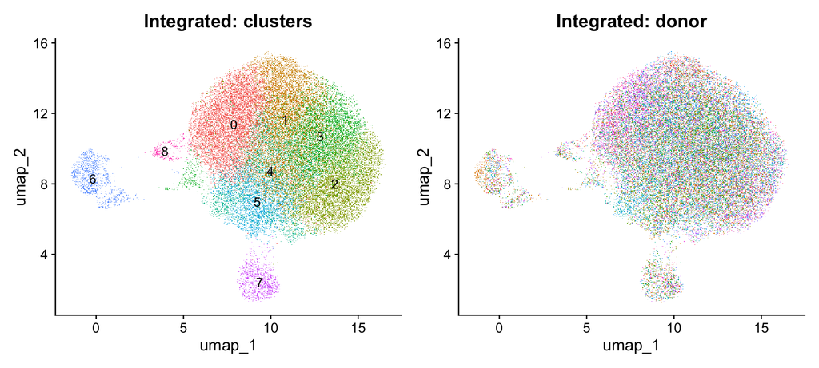

```r
gg1 <- Seurat::DimPlot(seurat_obj, reduction = "umap",
                       group.by = "scvi_clusters", label = TRUE,
                       raster = TRUE) +
  Seurat::NoLegend() +
  ggplot2::ggtitle("Integrated: clusters")
gg2 <- Seurat::DimPlot(seurat_obj, reduction = "umap",
                       group.by = "donor_id", raster = TRUE) +
  Seurat::NoLegend() +
  ggplot2::ggtitle("Integrated: donor")
plot(gg1 + gg2)
```

```r
purity_scvi <- donor_purity(seurat_obj$scvi_clusters, seurat_obj$donor_id)
purity_scvi
```

```
##   cluster n_cells top_donor_frac donors_for_half
## 1       0    8671     0.07461654              17
## 2       1    8118     0.07649667              15
## 3       2    8009     0.06005744              14
## 4       3    6046     0.06748263              17
## 5       4    3870     0.09741602              17
## 6       5    2859     0.06260930              15
## 7       6    1118     0.20840787              13
## 8       7    1034     0.03868472              22
## 9       8     275     0.13818182               6
```

```r
summary(purity_pca[, "top_donor_frac"])
```

```
##    Min. 1st Qu.  Median    Mean 3rd Qu.    Max.
## 0.06826 0.08616 0.10415 0.14435 0.17963 0.32805
```

```r
summary(purity_scvi[, "top_donor_frac"])
```

```
##    Min. 1st Qu.  Median    Mean 3rd Qu.    Max.
## 0.03868 0.06261 0.07462 0.09155 0.09742 0.20841
```

```r
sum(purity_pca[, "donors_for_half"] <= 3)
```

```
## [1] 1
```

```r
sum(purity_scvi[, "donors_for_half"] <= 3)
```

```
## [1] 0
```

**Integration helped, and by less than the introduction implied.** Uncorrected, the median cluster draws 10.4% of its cells from its top donor, the worst draws 32.8%, and **one** cluster gets half its cells from three donors or fewer. After integration the median falls to 7.5%, the worst to 20.8%, and **no** cluster is that concentrated.

# 6 Do the two clusterings agree?

Purity says the corrected clustering is less donor-driven. It does not say the two analyses found different *biology*. Cross-tabulate them.

```r
concordance_tab <- table(paste0("pca_", seurat_obj$pca_clusters),
                         paste0("scvi_", seurat_obj$scvi_clusters))
concordance_tab
```

```
##
##          scvi_0 scvi_1 scvi_2 scvi_3 scvi_4 scvi_5 scvi_6 scvi_7 scvi_8
##   pca_0    1160   3380   1214   1090    759    524      1      1      7
##   pca_1    1517    491    729   2195    321    107      6      5      2
##   pca_10     42      4     42      6      5      3     13      0    255
##   pca_11      1      0      0      3      0      4    294      1      0
##   pca_2    1303   1480    827    856    566     19      0      0      2
##   pca_3    1561    345   2531     94    227     67      1      0      4
##   pca_4    1441    174   1761    209    181     62      2      2      3
##   pca_5     444    564    326   1436    129    527      0      2      2
##   pca_6     160    162     99     20    117   1420     18   1022      0
##   pca_7     406   1456    234    112    428     10      0      0      0
##   pca_8     628     61    246     25   1136    112      2      0      0
##   pca_9       8      1      0      0      1      4    781      1      0
```

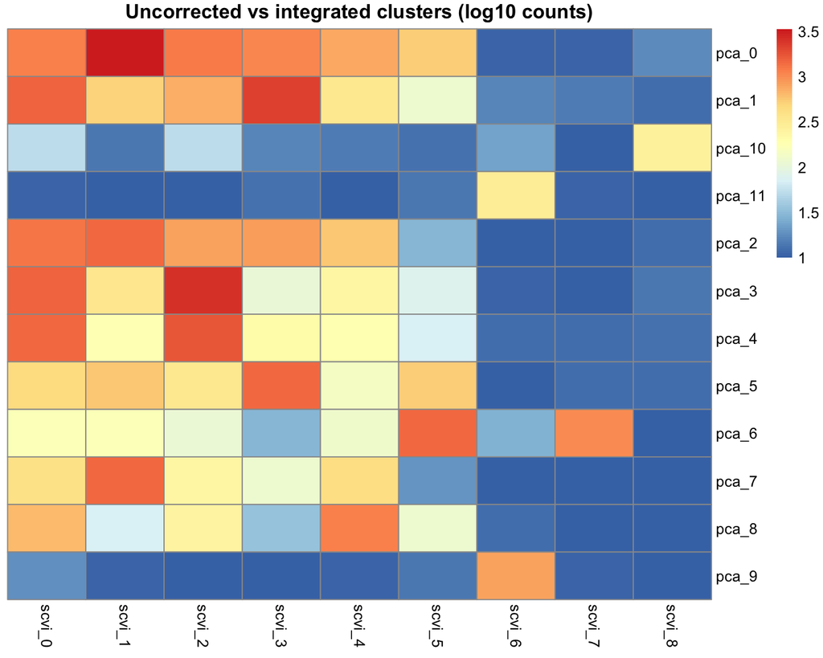

```r
pheatmap::pheatmap(log10(concordance_tab + 10),
                   cluster_rows = FALSE,
                   cluster_cols = FALSE,
                   main = "Uncorrected vs integrated clusters (log10 counts)")
```

The `log10(tab + 10)` is a display trick worth keeping: without the `+ 10`, the many zero cells dominate the colour scale and the structure disappears.

**How to read it.** One bright cell per row and per column — a near-permutation matrix — means the two methods recovered the same partition under different names. A row that spreads across several columns means that cluster was split by the other method; a column collecting several rows means it was merged.

# 7 Are the clusters stable?

Agreement between two methods is one kind of evidence. Another is whether a single method finds the same clusters again when you perturb the data. `bluster::bootstrapStability()` resamples the cells, re-clusters, and reports how consistently each original cluster is recovered.

```r
set.seed(10)
stability_cells <- sample(colnames(seurat_obj), 10000)
scvi_embedding <- Seurat::Embeddings(seurat_obj, "scVI")[stability_cells, ]
dim(scvi_embedding)
```

```
## [1] 10000    10
```

We subsample to 10,000 cells because this is the one genuinely expensive step — it re-clusters the data twenty times. That is a compute compromise, and worth stating rather than hiding.

```r
cluster_fun <- function(x) {
  graph_obj <- bluster::makeSNNGraph(x, type = "jaccard")
  igraph::cluster_louvain(graph_obj)$membership
}

set.seed(10)
original_clusters <- cluster_fun(scvi_embedding)
table(original_clusters)
```

```
## original_clusters
##    1    2    3    4    5    6    7    8    9   10   11   12   13   14
##  870 1071  303 1502 1175  647 1001 1060  722  810  369  287   49  134
```

```r
set.seed(10)
stability_mat <- bluster::bootstrapStability(scvi_embedding,
                                             FUN = cluster_fun,
                                             clusters = original_clusters)
dim(stability_mat)
```

```
## [1] 14 14
```

```r
round(diag(stability_mat), 2)
```

```
##    1    2    3    4    5    6    7    8    9   10   11   12   13   14
## 0.13 0.15 0.98 0.21 0.12 0.26 0.19 0.16 0.23 0.18 0.22 0.93 0.96 0.54
```

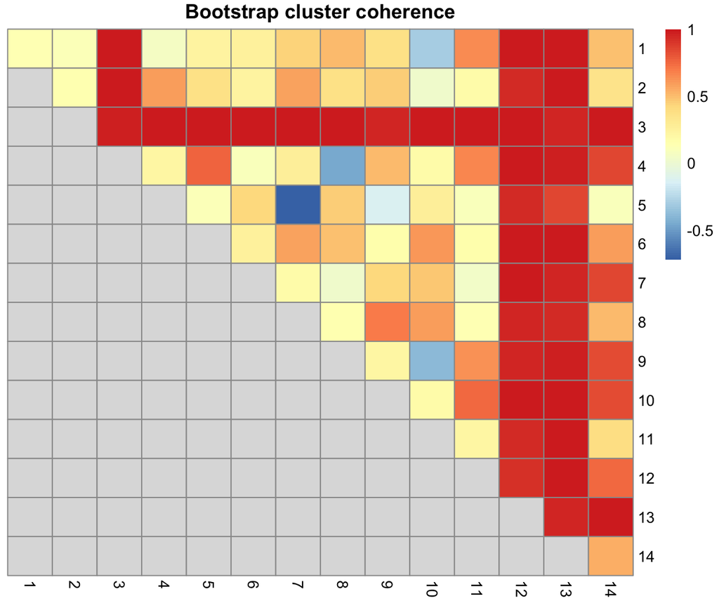

```r
pheatmap::pheatmap(stability_mat,
                   cluster_rows = FALSE,
                   cluster_cols = FALSE,
                   main = "Bootstrap cluster coherence")
```

The `bluster` documentation states the reading of this plot exactly right, so here it is verbatim:

> High on-diagonal values indicate that the corresponding cluster remains coherent in the bootstrap replicates, while high off-diagonal values indicate that the corresponding pair of clusters are still separated in the replicates.

A low diagonal entry is a cluster that dissolves when the data is perturbed — which does not mean it is fake, but does mean you should not build a story on it without other evidence.

**And this is the least comfortable result in the tutorial.** Of the 14 clusters found on the subsample, three come back with coherence above 0.9 (0.98, 0.96, 0.93) and one at 0.54. **The other ten sit between 0.12 and 0.26.** Resample the cells and most of these clusters do not reappear as the same groups.

Take that seriously rather than explaining it away. Microglia in cortex are not a set of cleanly separated cell types the way lymphocytes in blood are; much of the variation is a continuum of activation state, and cutting a continuum into communities is exactly the situation where the boundaries move under resampling. Three of these clusters look like genuinely distinct populations. The rest are better described as regions of a gradient than as types — and a Louvain algorithm will return them with the same confident integer labels either way.

> **What to do with an unstable cluster.** Not necessarily discard it. But do not name it as a cell type, do not build a downstream comparison that depends on its exact boundary, and do not report the number of clusters as a finding. If a result survives only at one resolution on one clustering, it is a property of the algorithm.

# 8 Choosing a resolution

`resolution` is the parameter with the largest effect on your conclusions and the least justification in most papers. There is no correct value; there is a value you can defend.

```r
set.seed(10)
seurat_obj <- Seurat::FindClusters(seurat_obj,
                                   resolution = c(0.1, 0.2, 0.5, 1.0),
                                   verbose = FALSE)

resolution_cols <- c("RNA_snn_res.0.1", "RNA_snn_res.0.2",
                     "RNA_snn_res.0.5", "RNA_snn_res.1")
sapply(resolution_cols,
       function(x) length(unique(seurat_obj@meta.data[, x])))
```

```
## RNA_snn_res.0.1 RNA_snn_res.0.2 RNA_snn_res.0.5   RNA_snn_res.1
##               4               6               9              17
```

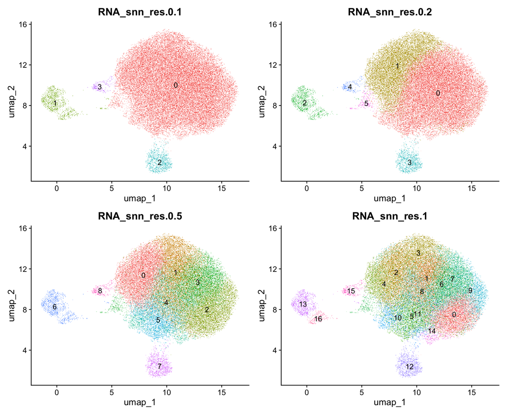

```r
gg_list <- lapply(resolution_cols, function(x) {
  Seurat::DimPlot(seurat_obj, reduction = "umap", group.by = x,
                  label = TRUE, raster = TRUE) +
    Seurat::NoLegend() +
    ggplot2::ggtitle(x)
})
plot(patchwork::wrap_plots(gg_list, ncol = 2))
```

## 8.1 Where are the cells actually dense?

Before either check, it is worth looking at the UMAP without any cluster colours on it. A `DimPlot` coloured by cluster shows you the partition you asked for, and a partition always looks like a partition — the colours tell you where the boundaries were drawn, not whether there was anything there to divide. Plotting the **density** of cells instead answers a different question: how many well-separated lumps does this embedding actually contain?

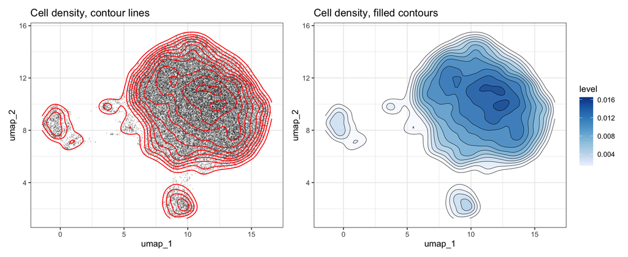

```r
umap_df <- Seurat::FetchData(seurat_obj, vars = c("umap_1", "umap_2"))

gg1 <- ggplot2::ggplot(umap_df, ggplot2::aes(x = umap_1, y = umap_2)) +
  ggplot2::geom_point(alpha = 0.15, size = 0.01) +
  ggplot2::geom_density2d(colour = "red", bins = 12) +
  ggplot2::ggtitle("Cell density, contour lines") +
  ggplot2::theme_bw()

gg2 <- ggplot2::ggplot(umap_df, ggplot2::aes(x = umap_1, y = umap_2)) +
  ggplot2::stat_density_2d(geom = "polygon", contour = TRUE,
                           ggplot2::aes(fill = ggplot2::after_stat(level)),
                           bins = 12, alpha = 0.4) +
  ggplot2::scale_fill_distiller(palette = "Blues", direction = 1) +
  ggplot2::geom_density2d(colour = "black", bins = 12, linewidth = 0.2) +
  ggplot2::ggtitle("Cell density, filled contours") +
  ggplot2::theme_bw()

plot(gg1 + gg2)
```

Count the separated masses, then count the peaks inside them. This embedding has **three small, cleanly detached islands** — far left, bottom centre, and a tiny one at the left edge of the main body — plus **one large mass containing about two internal peaks**. Call it four or five modes.

The same plot split by donor is the visual counterpart to the purity table.

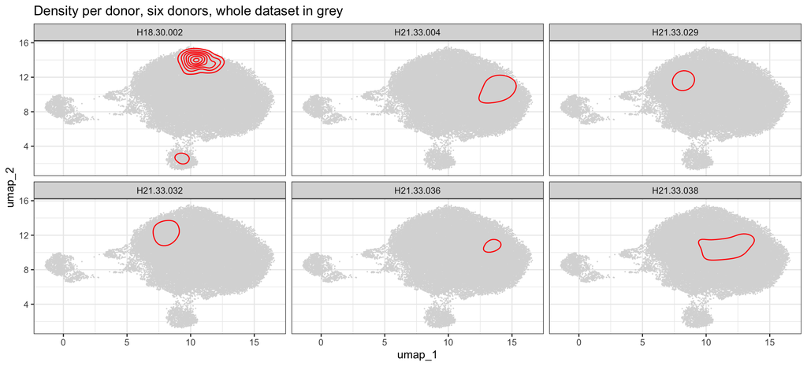

```r
set.seed(10)
donor_subset <- sample(unique(seurat_obj$donor_id), 6)

donor_df <- Seurat::FetchData(seurat_obj,
                              vars = c("umap_1", "umap_2", "donor_id"))
donor_df <- donor_df[donor_df$donor_id %in% donor_subset, ]

gg <- ggplot2::ggplot(donor_df, ggplot2::aes(x = umap_1, y = umap_2)) +
  ggplot2::geom_point(data = umap_df, colour = "grey85", size = 0.01) +
  ggplot2::geom_density2d(colour = "red", bins = 8) +
  ggplot2::facet_wrap(~ donor_id, ncol = 3) +
  ggplot2::ggtitle("Density per donor, six donors, whole dataset in grey") +
  ggplot2::theme_bw()
plot(gg)
```

No donor owns an island — which is the reassuring half, and matches the purity numbers. But look at *where inside the big mass* each donor peaks: six donors, six different modal positions, spread across the whole blob. The donor effect here is not “this person got their own cluster”; it is “this person sits slightly differently along a continuum”. That is a much harder thing to see in a cluster-coloured UMAP, and it is a good part of why boundaries drawn inside that mass move when you resample.

> **Read the peaks, not the absences.** A donor with few cells may produce no contour at all in a region where it does have cells — contouring needs density, so an empty facet region means “not enough cells to form a contour here”, not “no cells here”. Compare where the contours *are*, not where they are missing.

Two checks are more informative than staring at the panels.

**First: does raising the resolution split clusters into donor-specific pieces?** If new clusters appear that are dominated by a handful of donors, the resolution has passed the point where it is describing biology.

```r
purity_by_resolution <- lapply(resolution_cols, function(x) {
  purity_df <- donor_purity(seurat_obj@meta.data[, x], seurat_obj$donor_id)
  data.frame(resolution = x,
             n_clusters = nrow(purity_df),
             median_top_donor = median(purity_df[, "top_donor_frac"]),
             max_top_donor = max(purity_df[, "top_donor_frac"]),
             min_cluster_size = min(purity_df[, "n_cells"]))
})
do.call(rbind, purity_by_resolution)
```

```
##        resolution n_clusters median_top_donor max_top_donor min_cluster_size
## 1 RNA_snn_res.0.1          4       0.08984457     0.2047244              270
## 2 RNA_snn_res.0.2          6       0.07415231     0.2091153              242
## 3 RNA_snn_res.0.5          9       0.07461654     0.2084079              275
## 4   RNA_snn_res.1         17       0.08362818     0.2504409              227
```

Here the answer is **no** — and that is worth seeing, because the check is usually taught as if it always catches something. Across resolutions 0.1 to 1.0 the cluster count goes 4, 6, 9, 17 while the median top-donor share stays between 7.4% and 9.0% and the worst rises only from 20.5% to 25.0%. The smallest cluster never falls below 227 cells. On this dataset, turning the resolution up subdivides real structure rather than carving out individuals. On a dataset with fewer donors or stronger batch effects it will not, which is why you run it.

**Second: are the smallest clusters big enough to survive the next analysis?** The companion tutorial sums counts within one cell type per donor, and runs the same feasibility check before choosing which type to test. A cluster of 200 cells spread over 89 donors gives about two cells per donor — no donor-level comparison is possible, and the DE result for that cluster would be noise wearing a p-value.

```r
cells_tab <- table(seurat_obj$RNA_snn_res.0.2, seurat_obj$donor_id)
apply(cells_tab, 1,
      function(x) c(donors_with_10_or_more = sum(x >= 10),
                    median_cells = median(x)))
```

```
##
##                            0   1  2  3 4 5
##   donors_with_10_or_more  87  83 39 47 8 3
##   median_cells           234 107  9 10 1 2
```

This is the check that bites. At resolution 0.2, clusters 0 and 1 appear in 87 and 83 donors with at least ten cells (medians of 234 and 107 cells per donor). Clusters 2 and 3 manage 39 and 47 donors at a median of 9 and 10 cells. Clusters 4 and 5 reach 8 and 3 donors at a median of 1 and 2 cells.

So only two of these six clusters can support a donor-level comparison at all. The companion tutorial reaches the same conclusion from the other direction, and it is why it tests a single well-populated cell type rather than looping over everything.

> **The resolution is a downstream decision, not a visual one.** Pick it knowing what you intend to do next. If the plan is donor-level differential expression, the binding constraint is cells per donor per cluster, and that constraint is checkable before you commit.

We take **resolution 0.2** for the rest of this tutorial.

```r
Seurat::Idents(seurat_obj) <- "RNA_snn_res.0.2"
table(Seurat::Idents(seurat_obj))
```

```
##
##     0     1     2     3     4     5
## 25818 11507  1119  1038   276   242
```

# 9 Comparing two clusters

The first differential expression question of the session is the *easy* one: what distinguishes one cluster of cells from another? Here cells genuinely are the units of analysis — we are describing a partition of cells, not generalizing to new donors — so a cell-level test is the right tool.

```r
de_res <- Seurat::FindMarkers(seurat_obj,
                              ident.1 = "0",
                              ident.2 = "1",
                              test.use = "wilcox")
head(de_res, 10)
```

```
##                 p_val avg_log2FC pct.1 pct.2 p_val_adj
## ADAM7-AS1           0  -2.450405 0.350 0.823         0
## DLEU7               0  -2.551522 0.324 0.747         0
## ENSG00000228655     0  -2.423917 0.265 0.675         0
## ANKUB1              0  -2.387201 0.250 0.657         0
## ENSG00000254420     0  -2.279992 0.364 0.765         0
## FAM177B             0  -2.427470 0.248 0.618         0
## ENSG00000274441     0  -2.204946 0.255 0.613         0
## OPRM1               0  -2.536232 0.191 0.547         0
## ENSG00000229751     0  -2.241787 0.200 0.540         0
## ABHD15-AS1          0  -1.967155 0.363 0.701         0
```

```r
nrow(de_res)
```

```
## [1] 12982
```

`EnhancedVolcano` draws its horizontal line at a **raw** p-value, so passing `pCutoff = 0.05` would draw the line in the wrong place — that is an uncorrected threshold on 12,982 simultaneous tests. Convert the multiple-testing threshold you actually want into the raw p-value that corresponds to it, and pass that.

```r
bh_adj <- p.adjust(de_res$p_val, method = "BH")
sum(bh_adj < 0.05)
```

```
## [1] 9907
```

```r
p_threshold <- max(de_res$p_val[bh_adj < 0.05])
p_threshold
```

```
## [1] 0.03813603
```

Benjamini–Hochberg works by comparing the sorted p-values against a rising line, so “BH-significant at 0.05” corresponds to a single raw-p boundary — the largest raw p-value that still made the cut. That number is what the volcano’s line should sit at.

> **A useful diagnostic in general.** If a multiple-testing procedure leaves your threshold essentially where it started, ask why so few of your tests are null. Sometimes the answer is a genuinely strong effect. More often it means the null hypothesis being tested is not the one you think — as here, where the cells were selected for being different before they were tested for being different.

> **Note this is not the column Seurat gives you.** `p_val_adj` in a `FindMarkers()` table is a **Bonferroni** correction over every gene in the assay, which is far more conservative than BH and is computed over a different denominator than the genes actually tested here. We compute BH ourselves over the tested set rather than reusing that column.

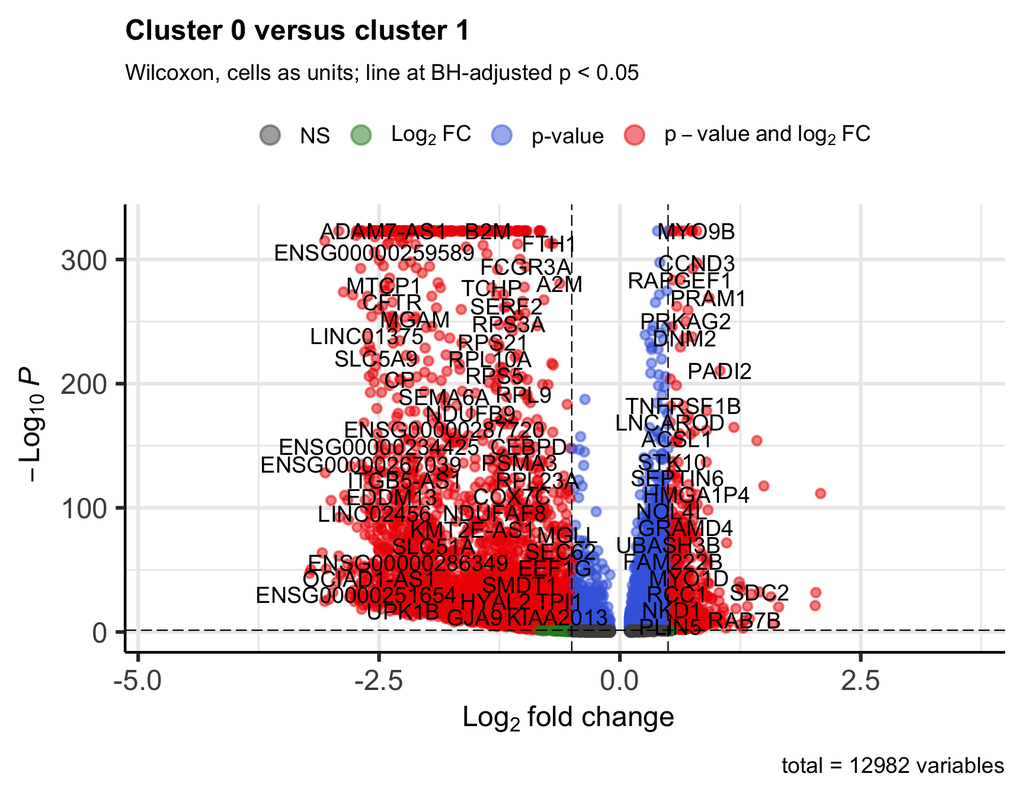

```r
gg <- EnhancedVolcano::EnhancedVolcano(
  de_res,
  lab = rownames(de_res),
  x = "avg_log2FC",
  y = "p_val",
  pCutoff = p_threshold,
  FCcutoff = 0.5,
  title = "Cluster 0 versus cluster 1",
  subtitle = "Wilcoxon, cells as units; line at BH-adjusted p < 0.05")
plot(gg)
```

> **Do not read these p-values as evidence.** The clusters were *defined* by finding the genes that separate these cells, and we are now testing those same cells for those same genes. The p-values are circular by construction, and the top ten come back as **exactly zero** — underflowing double precision. Use this ranking to **describe** clusters. Never quote it as proof that a cluster is real; the stability analysis above is for that, and it was a good deal less flattering.

Worth noticing what the top of that list actually contains: `ADAM7-AS1`, `DLEU7`, `ABHD15-AS1` and several bare `ENSG` identifiers — antisense transcripts, lncRNAs and unannotated features rather than recognizable marker genes. All ten are *lower* in cluster 0. A separation carried by unannotated features is not automatically wrong, but it is the signature of a technical axis (detection depth, annotation coverage) more often than a biological one, and it is a reason to look at cluster 0 versus 1 with suspicion rather than to start writing about `OPRM1` in microglia.

# 10 Marker genes

For naming clusters, what you want is genes that are up in one cluster against *all* others, not against one chosen rival.

```r
all_markers <- Seurat::FindAllMarkers(seurat_obj,
                                      only.pos = TRUE,
                                      test.use = "wilcox",
                                      min.pct = 0.25,
                                      logfc.threshold = 0.25,
                                      verbose = FALSE)
dim(all_markers)
```

```
## [1] 8443    7
```

```r
table(all_markers$cluster)
```

```
##
##    0    1    2    3    4    5
##  731  556 1632 1220 1626 2678
```

```r
top_markers <- do.call(rbind, lapply(split(all_markers, all_markers$cluster),
                                     function(x) {
  x <- x[order(x$avg_log2FC, decreasing = TRUE), ]
  head(x, 5)
}))
top_markers[, c("cluster", "gene", "avg_log2FC", "pct.1", "pct.2", "p_val_adj")]
```

```
##                   cluster            gene avg_log2FC pct.1 pct.2     p_val_adj
## 0.PADI2                 0           PADI2  1.2737733 0.609 0.403  0.000000e+00
## 0.PRAM1                 0           PRAM1  1.0410942 0.540 0.326  0.000000e+00
## 0.MYO1E                 0           MYO1E  0.9833975 0.552 0.408 2.540558e-223
## 0.NHSL1                 0           NHSL1  0.9456053 0.631 0.527 1.399455e-180
## 0.PTPRG                 0           PTPRG  0.9441937 0.358 0.306  1.993330e-32
## 1.ENSG00000234428       1 ENSG00000234428  2.7519710 0.445 0.130  0.000000e+00
## 1.DIAPH2-AS1            1      DIAPH2-AS1  2.6945087 0.411 0.127  0.000000e+00
## 1.DLEU7                 1           DLEU7  2.6202002 0.747 0.311  0.000000e+00
## 1.ENO4                  1            ENO4  2.6055022 0.390 0.107  0.000000e+00
## 1.ENSG00000255968       1 ENSG00000255968  2.5822558 0.434 0.130  0.000000e+00
## 2.CD2                   2             CD2 11.2449540 0.525 0.001  0.000000e+00
## 2.CD3E                  2            CD3E 10.7962619 0.351 0.001  0.000000e+00
## 2.TRGC2                 2           TRGC2 10.7368500 0.270 0.000  0.000000e+00
## 2.GPR174                2          GPR174 10.5599507 0.347 0.000  0.000000e+00
## 2.LINC01871             2       LINC01871 10.5145962 0.283 0.000  0.000000e+00
## 3.MARCO                 3           MARCO  7.1301479 0.293 0.004  0.000000e+00
## 3.RND3                  3            RND3  6.7624954 0.390 0.007  0.000000e+00
## 3.COLEC12               3         COLEC12  6.5593742 0.843 0.037  0.000000e+00
## 3.SCN9A                 3           SCN9A  6.0838402 0.438 0.020  0.000000e+00
## 3.CR1                   3             CR1  5.9001464 0.554 0.016  0.000000e+00
## 4.MKI67                 4           MKI67  9.4464273 0.464 0.001  0.000000e+00
## 4.TOP2A                 4           TOP2A  8.8917112 0.453 0.002  0.000000e+00
## 4.FAM111B               4         FAM111B  8.8900084 0.558 0.002  0.000000e+00
## 4.CDK1                  4            CDK1  8.6048305 0.275 0.001  0.000000e+00
## 4.NEIL3                 4           NEIL3  8.5340986 0.333 0.001  0.000000e+00
## 5.LINC00609             5       LINC00609  4.4406524 0.310 0.024 1.442451e-167
## 5.CFAP54                5          CFAP54  4.2747893 0.281 0.029 2.073095e-107
## 5.SLC7A11               5         SLC7A11  4.0203326 0.260 0.021 1.087328e-135
## 5.HYDIN                 5           HYDIN  3.9525498 0.360 0.024 5.824339e-220
## 5.ARHGEF26-AS1          5    ARHGEF26-AS1  3.9483442 0.302 0.016 6.122215e-235
```

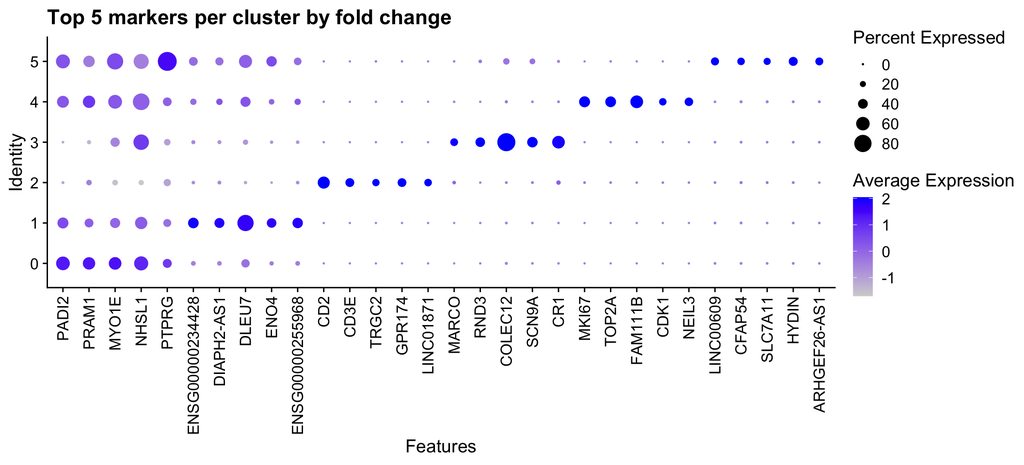

```r
marker_genes <- unique(top_markers[, "gene"])
gg <- Seurat::DotPlot(seurat_obj, features = marker_genes) +
  ggplot2::theme(axis.text.x = ggplot2::element_text(angle = 90, hjust = 1,
                                                     vjust = 0.5)) +
  ggplot2::ggtitle("Top 5 markers per cluster by fold change")
plot(gg)
```

## 10.1 Ranking by fold change is not the same as ranking by p-value

```r
cluster0_markers <- all_markers[all_markers$cluster == "0", ]

by_pval <- head(cluster0_markers[order(cluster0_markers$p_val), "gene"], 10)
by_fc <- head(cluster0_markers[order(cluster0_markers$avg_log2FC,
                                     decreasing = TRUE), "gene"], 10)

by_pval
```

```
##  [1] "PRAM1"  "PADI2"  "GNG7"   "NFIC"   "POU2F2" "RYR1"   "IGSF21" "MYO9B"
##  [9] "MYO1F"  "HS3ST4"
```

```r
by_fc
```

```
##  [1] "PADI2"    "PRAM1"    "MYO1E"    "NHSL1"    "PTPRG"    "ZBTB46"
##  [7] "HMGA1P4"  "ABR"      "CLIP2"    "GTF2IRD1"
```

```r
length(intersect(by_pval, by_fc))
```

```
## [1] 2
```

Sorting by p-value favours genes expressed in many cells, because that is what makes a Wilcoxon test confident. Sorting by fold change favours genes with big differences, which are often expressed in few cells. Neither is wrong.

**For cluster 0 the two top-ten lists share exactly two genes.** Eight of the ten markers you would put on a slide depend on which column you sorted by — a choice that is almost never stated in a figure legend, and one Seurat makes for you if you do not.

## 10.2 A curated panel beats a derived list for naming

Data-driven markers tell you what separates your clusters. They do not tell you what the clusters *are*. For that you need genes whose meaning was established elsewhere. Production pipelines for human brain tissue typically carry a large library of such panels, one per expected cell type; this is the microglial subset of one.

```r
panel_list <- list(
  homeostatic = c("P2RY12", "P2RY13", "CX3CR1", "TMEM119", "CSF1R", "SALL1"),
  activated = c("APOE", "SPP1", "GPNMB", "LPL", "ITGAX", "CD9"),
  antigen = c("CD74", "HLA-DRA", "HLA-DRB1"),
  pvm = c("CD163", "MRC1", "F13A1", "LYVE1"),
  lymphocyte = c("CD2", "CD3E", "IL7R", "SKAP1", "THEMIS", "CCL5"),
  proliferating = c("MKI67", "TOP2A"),
  other_lineage = c("SNAP25", "PLP1", "SLC1A2", "CLDN5")
)

panel_genes <- unlist(panel_list)
setdiff(panel_genes, rownames(seurat_obj))
```

```
## character(0)
```

```r
panel_genes <- intersect(panel_genes, rownames(seurat_obj))
```

> **Check that your genes exist before plotting them.** `setdiff()` against `rownames()` takes one line, and skipping it is how you end up presenting a panel with silent holes. It is worth wrapping in a helper if you plot panels often — a missing gene should degrade the figure, not error out or disappear. Here everything in the panel is present, which is the boring outcome and the one you want; on a mouse dataset, or an older annotation, or a targeted panel like the spatial data from Week 1, it will not be.

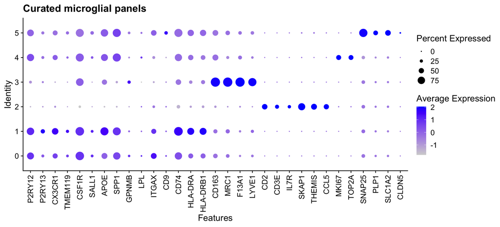

```r
gg <- Seurat::DotPlot(seurat_obj, features = panel_genes) +
  ggplot2::theme(axis.text.x = ggplot2::element_text(angle = 90, hjust = 1,
                                                     vjust = 0.5)) +
  ggplot2::ggtitle("Curated microglial panels")
plot(gg)
```

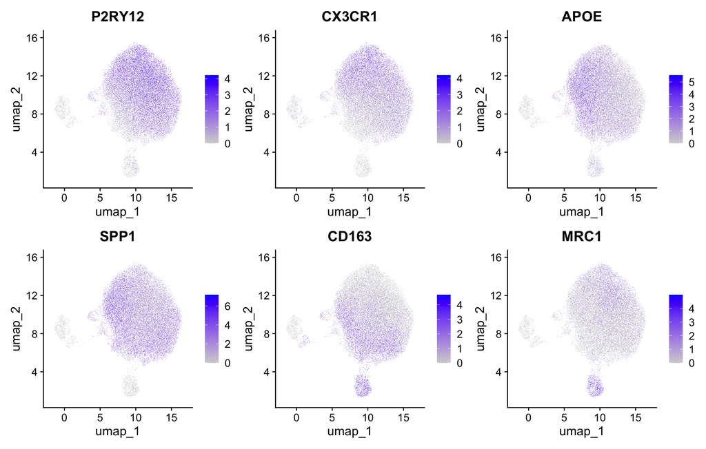

```r
gg <- Seurat::FeaturePlot(seurat_obj, reduction = "umap",
                          features = c("P2RY12", "CX3CR1", "APOE", "SPP1",
                                       "CD163", "MRC1"),
                          raster = TRUE, ncol = 3)
plot(gg)
```

**This one figure labels the whole dataset, and it is worth reading cluster by cluster.** Each panel lights up in exactly one place:

| Cluster | Cells | What the panel says |
| --- | --- | --- |
| 0 | 25,818 | Homeostatic microglia — `P2RY12`, `CX3CR1`, `CSF1R`, moderate `APOE`/`SPP1` |
| 1 | 11,507 | Microglia again, but with the antigen-presentation row (`CD74`, `HLA-DRA`, `HLA-DRB1`) markedly higher |
| 2 | 1,119 | **T lymphocytes** — the entire `lymphocyte` row, and nothing else |
| 3 | 1,038 | **Perivascular macrophages** — `CD163`, `MRC1`, `F13A1`, `LYVE1`, all four |
| 4 | 276 | **Proliferating cells** — `MKI67` and `TOP2A`, uniquely |
| 5 | 242 | **Not microglia** — `SNAP25`, `PLP1`, `SLC1A2`: neuronal, oligodendrocyte and astrocyte markers together |

That is a clean answer, and note how little of it came from the differential expression. The clusters were found without any of these genes; the panel simply read off what they are. Six clusters, six interpretable identities, from one dot plot.

Two of those rows deserve emphasis. **Cluster 5 expresses neuronal, oligodendrocyte *and* astrocyte markers simultaneously** — no real cell does that, so this is either doublets that survived Week 2’s filtering or nuclei carrying heavy ambient RNA. Yet SEA-AD labels 86% of it `Micro-PVM_2_3`. A published atlas annotation does not exempt you from looking. And **cluster 3 is perivascular macrophages**, which is a genuinely different cell type from microglia that the dataset’s name (`Microglia-PVM`) tells you to expect — if you had treated all 40,000 nuclei as one population, you would have averaged the two together.

The last two rows are quality-control panels, not biology panels. `SNAP25` is neuronal, `PLP1` oligodendrocyte, `SLC1A2` astrocyte, `CLDN5` endothelial. In a dataset subset to microglia, any cluster showing these is either a doublet population that survived Week 2’s filtering or ambient RNA from the surrounding tissue. Either way it is a finding about your data, and the companion tutorial shows how far that kind of contamination can propagate into a DE result.

> **The `lymphocyte` row is in this panel because the data put it there, and it is worth saying how.** The first draft of this tutorial had no lymphocyte markers — the QC row went straight from microglia to neurons, oligodendrocytes, astrocytes and endothelium, which is the standard brain contamination list. Then `FindAllMarkers()` returned `CD2`, `CD3E` and `TRGC2` as the top markers of cluster 2, at log2 fold changes above 10 with the genes detected in half that cluster and essentially none of the rest. Those are T-cell receptor and T-cell co-receptor genes. There is a lymphocyte population sitting inside a dataset labelled microglia-and-perivascular-macrophage — brain does contain resident and infiltrating T cells, so this is plausible biology rather than an error, but it is not microglia.

> **The curated panel would have missed it and the derived markers caught it.** That is the honest relationship between the two approaches: a panel encodes what you already expected to find, so it can only confirm or deny those things. `FindAllMarkers()` has no expectations. Run both, and when the data-driven list names something your panel does not cover, extend the panel — which is what the `lymphocyte` row is.

# 11 Checking against a reference annotation

Now bring back the label we set aside. SEA-AD’s `Supertype` was assigned by the atlas authors using far more data than we have here, so it is not truth — but it is independent of everything we just did.

```r
supertype_tab <- table(paste0("cluster_", Seurat::Idents(seurat_obj)),
                       seurat_obj$Supertype)
supertype_tab
```

```
##
##             Micro-PVM_1 Micro-PVM_1_1-SEAAD Micro-PVM_2 Micro-PVM_2_1-SEAAD
##   cluster_0         377                   2       12722                  84
##   cluster_1         209                   0        9627                   0
##   cluster_2           7                 258           4                   3
##   cluster_3        1021                   0           0                   0
##   cluster_4           0                   0          69                 202
##   cluster_5           7                   0           5                   0
##
##             Micro-PVM_2_2-SEAAD Micro-PVM_2_3-SEAAD Micro-PVM_3-SEAAD
##   cluster_0                   2                8026              4205
##   cluster_1                   1                 776               873
##   cluster_2                 831                   3                13
##   cluster_3                   0                   4                13
##   cluster_4                   0                   3                 2
##   cluster_5                  21                 207                 1
##
##             Micro-PVM_4-SEAAD
##   cluster_0               400
##   cluster_1                21
##   cluster_2                 0
##   cluster_3                 0
##   cluster_4                 0
##   cluster_5                 1
```

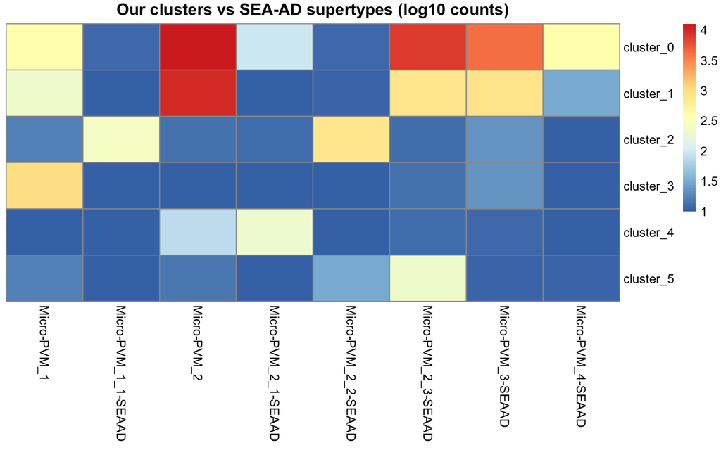

```r
pheatmap::pheatmap(log10(supertype_tab + 10),
                   cluster_rows = FALSE,
                   cluster_cols = FALSE,
                   main = "Our clusters vs SEA-AD supertypes (log10 counts)")
```

```r
round(prop.table(supertype_tab, margin = 1), 2)
```

```
##
##             Micro-PVM_1 Micro-PVM_1_1-SEAAD Micro-PVM_2 Micro-PVM_2_1-SEAAD
##   cluster_0        0.01                0.00        0.49                0.00
##   cluster_1        0.02                0.00        0.84                0.00
##   cluster_2        0.01                0.23        0.00                0.00
##   cluster_3        0.98                0.00        0.00                0.00
##   cluster_4        0.00                0.00        0.25                0.73
##   cluster_5        0.03                0.00        0.02                0.00
##
##             Micro-PVM_2_2-SEAAD Micro-PVM_2_3-SEAAD Micro-PVM_3-SEAAD
##   cluster_0                0.00                0.31              0.16
##   cluster_1                0.00                0.07              0.08
##   cluster_2                0.74                0.00              0.01
##   cluster_3                0.00                0.00              0.01
##   cluster_4                0.00                0.01              0.01
##   cluster_5                0.09                0.86              0.00
##
##             Micro-PVM_4-SEAAD
##   cluster_0              0.02
##   cluster_1              0.00
##   cluster_2              0.00
##   cluster_3              0.00
##   cluster_4              0.00
##   cluster_5              0.00
```

Rows are our clusters; each row shows how that cluster’s cells were labelled by SEA-AD. A cluster that maps cleanly onto one supertype has independent support. A cluster that splits a supertype may be finer structure, or may be noise.

That is not a failure of the analysis. It is the actual structure of the data: **a few genuinely separate cell types, plus a large microglial continuum that clustering reports as though it were made of types.** Knowing which of your clusters is which kind is the difference between a defensible figure and an overinterpreted one — and it took three independent checks, none of which was a p-value.

> **Disagreement is not automatically your error.** A reference built on a different cohort, at a different resolution, with a different objective, will disagree in places. The value of the comparison is that it tells you *where* to look, not who is right.

# 12 What we glossed over

- **We used someone else’s integration.** The `scVI` embedding came with the file. Running scVI yourself needs Python and `scvi-tools`; Harmony and `IntegrateLayers()` are the in-R alternatives shown in **Week 3**. Comparing integration methods head to head — with the purity and concordance measures used above — is the natural next step and was not done here.
- **Clustering algorithm.** We used Louvain, Seurat’s default. Leiden (`algorithm = 4`) is generally better behaved and guarantees connected communities. Running both and comparing them with the concordance heatmap used above is a cheap check that your clusters are not an artifact of one algorithm.
- **Number of PCs, for the uncorrected route only.** The integrated route used all 10 scVI dimensions because that is all there are. The choice matters more than the resolution in some datasets and we changed only one of them at a time.
- **Doublets and ambient RNA.** This object arrives pre-cleaned by the SEA-AD authors, so **Week 2**’s material is invisible here. Your own data will not arrive that way, and the `other_lineage` panel above is how you check.
- **Composition testing.** We counted cells per cluster per donor to check feasibility. Asking whether those *proportions* differ between disease groups is a genuine analysis with its own methods (`scCODA`, `propeller`), and it is not the same thing as differential expression.
- **Automated cell-type labelling.** MapMyCells and Azimuth assign labels against a reference directly, rather than clustering first and naming afterwards. Week 3 used Azimuth on blood; the brain references are the relevant ones here.
- **Cluster-level multiple testing.** `FindAllMarkers()` computes a Bonferroni adjustment within each cluster, over all genes. It does not adjust across clusters, and the clusters were chosen from the same data.

# 13 References

- Hao Y *et al.* (2024). “Dictionary learning for integrative, multimodal and scalable single-cell analysis” (Seurat v5). *Nature Biotechnology* 42:293–304. [doi:10.1038/s41587-023-01767-y](https://doi.org/10.1038/s41587-023-01767-y)
- Lun ATL, Risso D. `bluster`: clustering algorithms and cluster diagnostics. https://bioconductor.org/packages/bluster
- Traag VA, Waltman L, van Eck NJ (2019). “From Louvain to Leiden: guaranteeing well-connected communities.” *Scientific Reports* 9:5233. [doi:10.1038/s41598-019-41695-z](https://doi.org/10.1038/s41598-019-41695-z)
- Lopez R *et al.* (2018). “Deep generative modeling for single-cell transcriptomics” (scVI). *Nature Methods* 15:1053–1058. [doi:10.1038/s41592-018-0229-2](https://doi.org/10.1038/s41592-018-0229-2)
- Prater KE, Lin KZ (2025). “All the single cells: single-cell transcriptomics/epigenomics experimental design and analysis considerations for glial biologists.” *Glia* 73:451–473. [doi:10.1002/glia.24633](https://doi.org/10.1002/glia.24633) — §3.5 on cluster stability and §3.6 on cell type annotation cover this tutorial directly.
- Gabitto MI *et al.* (2024). “Integrated multimodal cell atlas of Alzheimer’s disease” (SEA-AD). *Nature Neuroscience*. https://portal.brain-map.org/explore/seattle-alzheimers-disease